# Universidad Autonoma del Estado de México

# Centro Universitario UAEM Zumpango

## Ingenería en Computación

## Graﬁcación Computacional

**Alumno**: Diego Argel Navarrete Godines

**Profesora**: Hazem Álvarez Rodríguez

**Fecha**: 19 de agosto del 2024

# Modelo Lotka – Volterra

## El modelo depredador-presa es un conjunto de ecuaciones matemáticas que describe las inámicas de poblaciones biológicas, particularmente en el contexto de las interacciones entre depredadores y presas. Fue propuesto de forma independiente por Alfred J. Lotka(1880–1949) en 1925 y por Vito Volterra (1860–1940) en 1926. Este modelo se utiliza para analizar la evolución de dos especies que interactúan en un entorno, donde una actúa como presa y la otra como depredador.

## El modelo se compone de dos ecuaciones diferenciales de primer grado:

## Ecuación para la población de presas:

## 𝑑𝑁/𝑑𝑡 = 𝛼𝑁 − 𝛽𝑁𝑃

## Donde:

## 𝑁 𝑒𝑠 𝑙𝑎 𝑝𝑜𝑏𝑙𝑎𝑐𝑖𝑜𝑛 𝑑𝑒 𝑙𝑎𝑠 𝑝𝑟𝑒𝑠𝑎𝑠.

## 𝑃 𝑒𝑠 𝑙𝑎 𝑝𝑜𝑏𝑙𝑎𝑐𝑖𝑜𝑛 𝑑𝑒 𝑙𝑜𝑠 𝑑𝑒𝑝𝑟𝑒𝑑𝑎𝑑𝑜𝑟𝑒𝑠.

## 𝛼 𝑒𝑠 𝑙𝑎 𝑡𝑎𝑠𝑎 𝑑𝑒 𝑐𝑟𝑒𝑐𝑖𝑚𝑖𝑒𝑛𝑡𝑜 𝑛𝑎𝑡𝑢𝑟𝑎𝑙 𝑑𝑒 𝑙𝑎𝑠 𝑝𝑟𝑒𝑠𝑎𝑠.

## 𝛽 𝑒𝑠 𝑙𝑎 𝑡𝑎𝑠𝑎 𝑑𝑒 𝑑𝑒𝑝𝑟𝑒𝑑𝑎𝑐𝑖𝑜𝑛 𝑜 𝑙𝑎 𝑡𝑎𝑠𝑎 𝑎 𝑙𝑎 𝑐𝑢𝑎𝑙 𝑙𝑜𝑠 𝑑𝑒𝑝𝑟𝑒𝑑𝑎𝑑𝑜𝑟𝑒𝑠 𝑐𝑎𝑝𝑎𝑡𝑢𝑟𝑎𝑛 𝑝𝑟𝑒𝑠𝑎𝑠.

## Ecuación para la población de depredadores:

## 𝑑𝑃 / 𝑑𝑡 = 𝛿𝑁𝑃 − 𝛾𝑃

## Donde:

## 𝛿 𝑒𝑠 𝑙𝑎 𝑡𝑎𝑠𝑎 𝑑𝑒 𝑐𝑟𝑒𝑐𝑖𝑚𝑖𝑒𝑛𝑡𝑜 𝑑𝑒 𝑙𝑎 𝑝𝑜𝑏𝑙𝑎𝑐𝑖ó𝑛 𝑞𝑢𝑒 𝑑𝑒𝑝𝑒𝑛𝑑𝑒 𝑑𝑒 𝑙𝑎 𝑝𝑟𝑒𝑠𝑎𝑠.

## 𝛾 𝑒𝑠 𝑙𝑎 𝑡𝑎𝑠𝑎 𝑑𝑒 𝑚𝑜𝑟𝑡𝑎𝑙𝑖𝑑𝑎𝑑 𝑛𝑎𝑡𝑢𝑟𝑎𝑙 𝑑𝑒 𝑙𝑜𝑠 𝑑𝑒𝑝𝑟𝑒𝑑𝑎𝑑𝑜𝑟𝑒𝑠.

## Para aplicar el modelo de depredador – presa de Lotka – Volterra hablando computacionalmente, debemos adatar sus ecuaciones diferenciales a un formato que pueda ser manejado por un lenguaje de programación en este caso es Python, estas ecuaciones nos ayudaran a describir como las poblaciones cambian con el tiempo, este enfoque convierte las ecuaciones diferenciales que se pueden resolver numéricamente mediante la iteración, esto nos permite simular el comportamiento y podemos observar las poblaciones a largo del tiempo y analizar su evolución graficando los resultado utilizando Python.

# El siguiente ejemplo es la implementación del modelo de depredador – presa en Python.

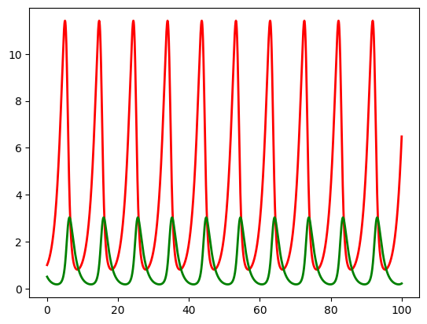

```python
import matplotlib.pyplot as plt
from random import *
from numpy import *
import sys

# model parameters
# rojo = presas , verdes = depredadores
# a = aumento natural, b = destruccion por depredadores, c = muerte en ausencia de presa y e = aumento causado alimentacion alimentacion
a = 0.7; b = 0.7; c = 0.8;  e = 0.2

# punto de equilibrio a = 0.3; b = 0.2; c = 0.6; e = 0.3
#a = 0.8; b = 0.3; c = 0.3;  e = 0.2


dt = 0.001; max_time = 100

# initial time and populations
t = 0; x = 1.0; y = 0.5

# empty lists in which to store time and populations
t_list = []; x_list = []; y_list = []

# initialize lists
t_list.append(t); x_list.append(x); y_list.append(y)

while t < max_time:
    # calc new values for t, x, y
    t = t + dt
    x = x + (a*x - b*x*y)*dt
    y = y + (-c*y + e*x*y)*dt

    # store new values in lists
    t_list.append(t)
    x_list.append(x)
    y_list.append(y)

# Plot the results
p = plt.plot(t_list, x_list, 'r', t_list, y_list, 'g', linewidth = 2)
plt.show()
```

#### Primero, se importan las librerías necesarias, aunque algunas no se usan en este fragmento. Luego, se definen los parámetros del modelo y se inicializan las variables de tiempo y poblaciones. Se crean listas para almacenar los resultados de tiempo y poblaciones durante la simulación.

## A continuación, se mostrar 5 distintas variaciones en los parámetros durante la simulación de las poblaciones.

## Las líneas rojo representa las presas y las líneas verdes representan los depredadores enla población. El parámetro “a” es el aumento natural de la especie, el parámetro “b” es la destrucción por depredadores, el parámetro “c” es la muerte en ausencia de presa y el parámetro “e” es el aumento causado por la alimentación. Dicho lo anterior podemos observar la variante uno.

## 𝑣𝑎𝑟𝑖𝑎𝑛𝑡𝑒 1 ∶ 𝑎 = 0.8, 𝑏 = 0.3, 𝑐 = 0.3 𝑦 𝑒 = 0.2

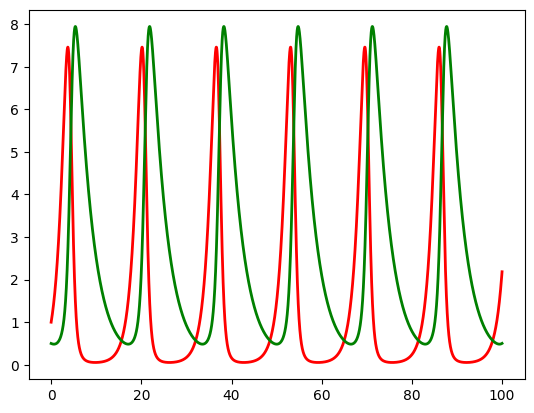

```python
import matplotlib.pyplot as plt
from random import *
from numpy import *
import sys

# model parameters
a = 0.8; b = 0.3; c = 0.3; e = 0.2
dt = 0.001; max_time = 100

# initial time and populations
t = 0; x = 1.0; y = 0.5

# empty lists in which to store time and populations
t_list = []; x_list = []; y_list = []

# initialize lists
t_list.append(t); x_list.append(x); y_list.append(y)

while t < max_time:
    # calc new values for t, x, y
    t = t + dt
    x = x + (a*x - b*x*y)*dt
    y = y + (-c*y + e*x*y)*dt

    # store new values in lists
    t_list.append(t)
    x_list.append(x)
    y_list.append(y)

# Plot the results
p = plt.plot(t_list, x_list, 'r', t_list, y_list, 'g', linewidth = 2)
plt.show()
```

### Al tener un índice relativamente alto en el aumento natural de la especie en 0.8 lo que significa presas crecen de manera rápida y la ausencia de los depredadores lo que lleva a un cantidad de presas considerablemente altas con una destrucción por los depredadores con un valor de 0.3 en este caso son muy eficaces en la captura de sus presas pero a la vez pueden acabar con la mayoría de las presas, la muerte en ausencia de las presas con un 0.3 y por el aumento causado por la alimentación disponible.

## 𝑣𝑎𝑟𝑖𝑎𝑛𝑡𝑒 2 ∶ 𝑎 = 0.5, 𝑏 = 0.7, 𝑐 = 0.5 𝑦 𝑒 = 0.3

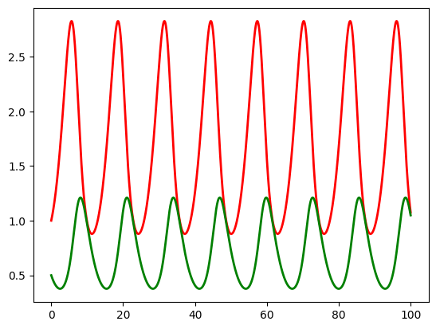

```python
import matplotlib.pyplot as plt
from random import *
from numpy import *
import sys

# model parameters
a = 0.5; b = 0.7; c = 0.5; e = 0.3
dt = 0.001; max_time = 100

# initial time and populations
t = 0; x = 1.0; y = 0.5

# empty lists in which to store time and populations
t_list = []; x_list = []; y_list = []

# initialize lists
t_list.append(t); x_list.append(x); y_list.append(y)

while t < max_time:
    # calc new values for t, x, y
    t = t + dt
    x = x + (a*x - b*x*y)*dt
    y = y + (-c*y + e*x*y)*dt

    # store new values in lists
    t_list.append(t)
    x_list.append(x)
    y_list.append(y)

# Plot the results
p = plt.plot(t_list, x_list, 'r', t_list, y_list, 'g', linewidth = 2)
plt.show()
```

### En este caso las presas crecen más lentamente en ausencia de depredadores con un valor de 0.5 esto nos puede llevar a la tasa de depredación alta, lo que indica que los depredadores son muy eficientes a la ahora de cazar las presas con un valor de 0.7 pero los depredadores tienen una tasa de mortalidad moderada en ausencia de presas, lo que limita su supervivencia sin alimento con un valor del 0.5 y su tasa de crecimiento de los depredadores basada en la disponibilidad de presas es de 0.3 lo que puede llevar disponibilidad de presas para poder sobrevivir

## 𝑣𝑎𝑟𝑖𝑎𝑛𝑡𝑒 3∶ 𝑎 = 0.3, 𝑏 = 0.2, 𝑐 = 0.6 𝑦 𝑒 = 0.4

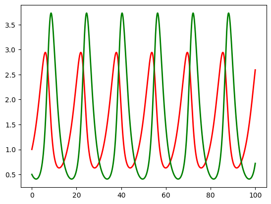

```python
import matplotlib.pyplot as plt
from random import *
from numpy import *
import sys

# model parameters
a = 0.3; b = 0.2; c = 0.6; e = 0.4
dt = 0.001; max_time = 100

# initial time and populations
t = 0; x = 1.0; y = 0.5

# empty lists in which to store time and populations
t_list = []; x_list = []; y_list = []

# initialize lists
t_list.append(t); x_list.append(x); y_list.append(y)

while t < max_time:
    # calc new values for t, x, y
    t = t + dt
    x = x + (a*x - b*x*y)*dt
    y = y + (-c*y + e*x*y)*dt

    # store new values in lists
    t_list.append(t)
    x_list.append(x)
    y_list.append(y)

# Plot the results
p = plt.plot(t_list, x_list, 'r', t_list, y_list, 'g', linewidth = 2)
plt.show()
```

## En la variante 3 el parámetros de las presas tienen una tasa de crecimiento natural muy baja puesto que crecen de manera lenta en ausencia de depredadores con un valor de 0.3, en la a tasa de depredación es baja con un valor de 0.2 lo que significa que los depredadores no son muy efectivos en la captura de presas, al tener una eficiencia en la casa le genera a los depredadores una alta tasa de mortalidad en ausencia de presas con un valor de 0.6 y por ultimo la tasa de crecimiento de los depredadores basada en la disponibilidad de presas es alta con un valor de 0.4.

## 𝑣𝑎𝑟𝑖𝑎𝑛𝑡𝑒 4 ∶ 𝑎 = 0.7, 𝑏 = 0.5 , 𝑐 = 0.2 𝑦 𝑒 = 0.1

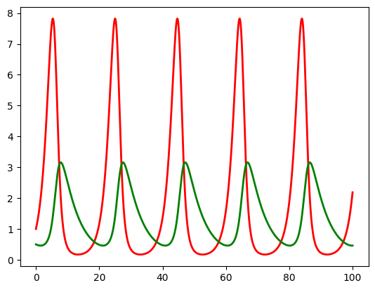

```python
import matplotlib.pyplot as plt
from random import *
from numpy import *
import sys

# model parameters
a = 0.7; b = 0.5; c = 0.2; e = 0.1
dt = 0.001; max_time = 100

# initial time and populations
t = 0; x = 1.0; y = 0.5

# empty lists in which to store time and populations
t_list = []; x_list = []; y_list = []

# initialize lists
t_list.append(t); x_list.append(x); y_list.append(y)

while t < max_time:
    # calc new values for t, x, y
    t = t + dt
    x = x + (a*x - b*x*y)*dt
    y = y + (-c*y + e*x*y)*dt

    # store new values in lists
    t_list.append(t)
    x_list.append(x)
    y_list.append(y)

# Plot the results
p = plt.plot(t_list, x_list, 'r', t_list, y_list, 'g', linewidth = 2)
plt.show()
```

### En la variante 4 en este caso las presas crecen a un ritmo relativamente muy elevadopuesto que hay ausencia de depredadores este toma el valor de 0.7 para la tasa de depredación es alta con un valor de 0,5 lo que significa que los depredadores son bastante rápidos en la captura de presas, la tasa de mortalidad de los depredadores en ausencia de presas es muy baja lo que permite sobrevivir un poco más de tiempo la tasa de crecimiento de los depredadores basada en la disponibilidad de presas es baja, por lo que los depredadores no crecen tan rápido a pesar la cantidad de presas es alta a comparación con los depredadores.

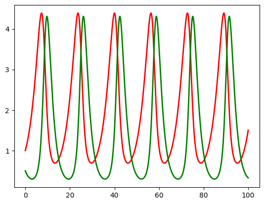

```python
import matplotlib.pyplot as plt
from random import *
from numpy import *
import sys

# model parameters
a = 0.3; b = 0.2; c = 0.6; e = 0.3
dt = 0.001; max_time = 100

# initial time and populations
t = 0; x = 1.0; y = 0.5

# empty lists in which to store time and populations
t_list = []; x_list = []; y_list = []

# initialize lists
t_list.append(t); x_list.append(x); y_list.append(y)

while t < max_time:
    # calc new values for t, x, y
    t = t + dt
    x = x + (a*x - b*x*y)*dt
    y = y + (-c*y + e*x*y)*dt

    # store new values in lists
    t_list.append(t)
    x_list.append(x)
    y_list.append(y)

# Plot the results
p = plt.plot(t_list, x_list, 'r', t_list, y_list, 'g', linewidth = 2)
plt.show()
```